# Customer Insights – A Statistical Investigation

## Unlocking Customer Insights: A Statistical Investigation

## Project Description

Apply descriptive statistics, exploratory data analysis, visualizations, and hypothesis testing to investigate behavioural patterns, spending trends, and demographic influences in a real-world customer dataset.

## Business Problem Statement

A mid-sized Indian retail company is sitting on a treasure trove of customer data — but lacks clarity on what story it tells. They need a team of analysts to conduct a rigorous statistical investigation to validate business assumptions, uncover hidden patterns, and support data-driven decision-making.

## Understanding The Data

```python
# step 1: importing required libraries

import pandas as pd
import numpy as np

#--------------------------------------------------------------------------------
# Step 2: Define file paths (assuming the datasets are in the 'data/' folder)
#--------------------------------------------------------------------------------
Cust_Data=pd.read_csv(r"C:\Users\INDIA\Downloads\4453500-Dataset (1)\Dataset\US_Customer_Insights_Dataset.csv")

#----------------------------------------------------------------------------------
# Step 3: Preview the first few records of each dataset
#----------------------------------------------------------------------------------
print("\n Customer Data:\n")
display(Cust_Data.head())

#------------------------------------------------------------------------------------
# Show column-level information including data types
#------------------------------------------------------------------------------------
print("\n Information About Data:\n")
Cust_Data.info()

#-------------------------------------------------------------------------------------
# Checking unique values
#-------------------------------------------------------------------------------------
print("\n Unique Values:\n")
unique=Cust_Data.nunique()
display(unique)

#--------------------------------------------------------------------------------------
#  count of non-null values
#--------------------------------------------------------------------------------------
print("\n Count of null values:\n")
is_null=Cust_Data.isnull().sum()
display(is_null)

#--------------------------------------------------------------------------------------
# Understanding which variables are categorical and which are numerical
#--------------------------------------------------------------------------------------
print("\n Checking The categorical and numerical variables:\n")
num_cols = Cust_Data.select_dtypes(include='number').columns.tolist()
cat_cols = Cust_Data.select_dtypes(exclude='number').columns.tolist()

print("Numerical Columns:", num_cols)
print("Categorical Columns:", cat_cols)

#-----------------------------------------------------------------------------------------
```

```
 Customer Data:
```

|  | CustomerID | Name | State | Education | Gender | Age | Married | NumPets | JoinDate | TransactionDate | MonthlySpend | DaysSinceLastInteraction |
| --- | --- | --- | --- | --- | --- | --- | --- | --- | --- | --- | --- | --- |
| 0 | CUST10319 | Scott Perez | Florida | High School | Non-Binary | 47 | Yes | 1 | 9/19/21 | 9/2/24 | 1281.74 | 332 |
| 1 | CUST10695 | Jennifer Burton | Washington | Master | Male | 72 | Yes | 0 | 4/5/24 | 6/2/24 | 429.46 | 424 |
| 2 | CUST10297 | Michelle Rogers | Arizona | Master | Female | 40 | Yes | 2 | 7/24/24 | 2/28/25 | 510.34 | 153 |
| 3 | CUST10103 | Brooke Hendricks | Texas | Master | Male | 27 | Yes | 0 | 8/12/23 | 3/29/25 | 396.47 | 124 |
| 4 | CUST10219 | Karen Johns | Texas | High School | Female | 28 | Yes | 1 | 12/6/21 | 7/24/22 | 139.68 | 1103 |

```
 Information About Data:

<class 'pandas.core.frame.DataFrame'>
RangeIndex: 10675 entries, 0 to 10674
Data columns (total 12 columns):
 #   Column                    Non-Null Count  Dtype
---  ------                    --------------  -----
 0   CustomerID                10675 non-null  object
 1   Name                      10675 non-null  object
 2   State                     10675 non-null  object
 3   Education                 10675 non-null  object
 4   Gender                    10675 non-null  object
 5   Age                       10675 non-null  int64
 6   Married                   10675 non-null  object
 7   NumPets                   10675 non-null  int64
 8   JoinDate                  10675 non-null  object
 9   TransactionDate           10675 non-null  object
 10  MonthlySpend              10675 non-null  float64
 11  DaysSinceLastInteraction  10675 non-null  int64
dtypes: float64(1), int64(3), object(8)
memory usage: 1000.9+ KB

 Unique Values:
```

```
CustomerID                  1000
Name                         990
State                         10
Education                      5
Gender                         3
Age                           63
Married                        2
NumPets                        5
JoinDate                     731
TransactionDate             1605
MonthlySpend                9843
DaysSinceLastInteraction    1605
dtype: int64
```

```
 Count of null values:
```

```
CustomerID                  0
Name                        0
State                       0
Education                   0
Gender                      0
Age                         0
Married                     0
NumPets                     0
JoinDate                    0
TransactionDate             0
MonthlySpend                0
DaysSinceLastInteraction    0
dtype: int64
```

```
 Checking The categorical and numerical variables:

Numerical Columns: ['Age', 'NumPets', 'MonthlySpend', 'DaysSinceLastInteraction']
Categorical Columns: ['CustomerID', 'Name', 'State', 'Education', 'Gender', 'Married', 'JoinDate', 'TransactionDate']
```

## Descriptive Statistics

Describing the customer base — how old they are, how much they spend, and how active they are.

```python
#----------------------------------------------------------------------------------------
# Mean, median, std dev for Age, MonthlySpend, DaysSinceLastInteraction
#----------------------------------------------------------------------------------------
print("\n|Avg , Median And StdDev for Age,MonthlySpend,DaySincsLastInteraction|:")
num_cols = ['Age','NumPets','MonthlySpend','DaysSinceLastInteraction']
display(Cust_Data[num_cols].agg(["mean","median","std"]))

#----------------------------------------------------------------------------------------
# Mode for categorical variables: Gender, Education, Married
#-----------------------------------------------------------------------------------------
print("\nMost Frequent Values In Education, Gender, Married:")
cat_cols= ['Education', 'Gender', 'Married']
display(Cust_Data[cat_cols].agg("mode"))
```

```
|Avg , Median And StdDev for Age,MonthlySpend,DaySincsLastInteraction|:
```

|  | Age | NumPets | MonthlySpend | DaysSinceLastInteraction |
| --- | --- | --- | --- | --- |
| mean | 49.474567 | 1.340515 | 331.610315 | 538.469883 |
| median | 49.000000 | 1.000000 | 282.110000 | 445.000000 |
| std | 18.221365 | 1.150849 | 225.799253 | 398.766747 |

```
Most Frequent Values In Education, Gender, Married:
```

|  | Education | Gender | Married |
| --- | --- | --- | --- |
| 0 | Master | Male | No |

## Data Visualization

Reveal patterns that numbers alone can’t show.

Plot histograms and boxplots for **Age** and **Monthly Spend**.

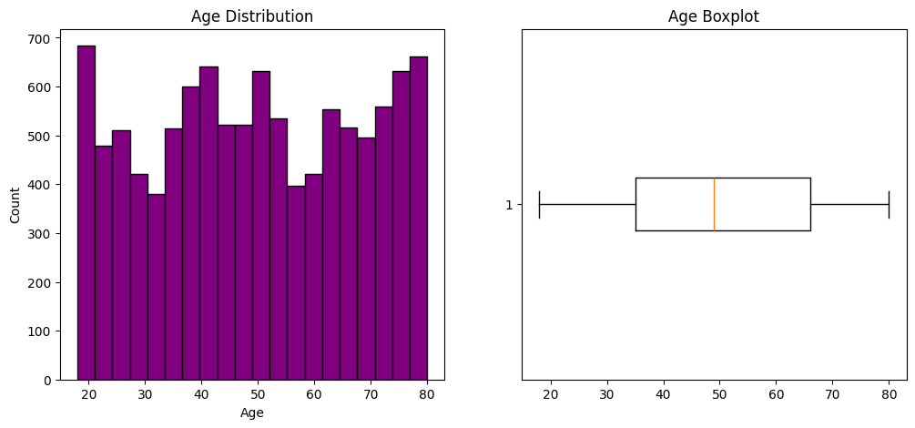

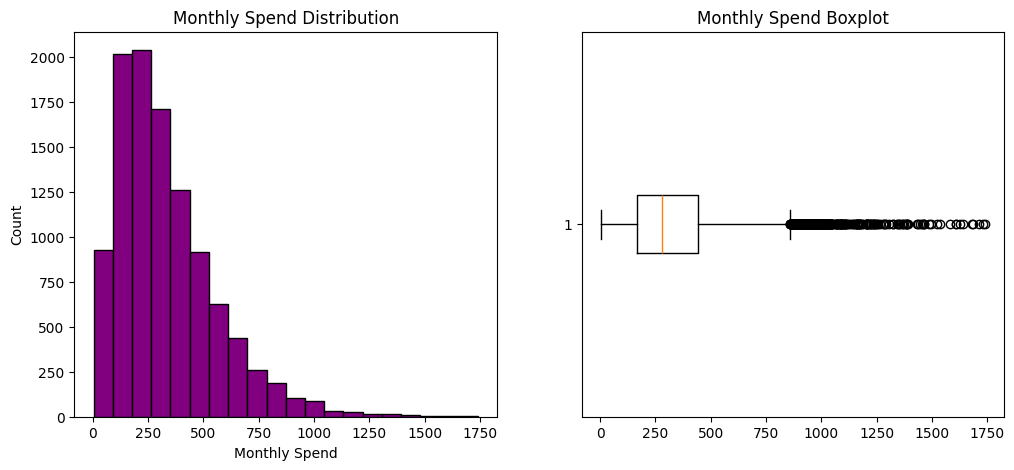

```python
# importing important libaries
#--------------------------------

import matplotlib.pyplot as plt
import seaborn as sns

# Create a new figure with width = 12 and height = 5 inches
plt.figure(figsize=(12,5))

#------------------------------------------------------------------------
# Create the first subplot (1 row, 2 columns, position 1)
plt.subplot(1,2,1)

# Plot histogram of Age column
plt.hist(Cust_Data['Age'], bins=20, color="purple", edgecolor="black")

# Label x-axis
plt.xlabel("Age")

# Label y-axis
plt.ylabel("Count")

# Title of the histogram
plt.title("Age Distribution")

#---------------------------------------------------------------------
# Create the second subplot (1 row, 2 columns, position 2)
plt.subplot(1,2,2)

# Plot boxplot for Age (horizontal)
plt.boxplot(Cust_Data['Age'], vert=False)

# Title of the boxplot
plt.title("Age Boxplot")

# Display the figure
plt.show()

#-------------------------------------------------------------------------------
# Create another figure for MonthlySpend analysis
plt.figure(figsize=(12,5))

# First subplot for MonthlySpend histogram
plt.subplot(1,2,1)

# Plot histogram of MonthlySpend column
plt.hist(Cust_Data['MonthlySpend'], bins=20, color="purple", edgecolor="black")

# Label x-axis
plt.xlabel("Monthly Spend")

# Label y-axis
plt.ylabel("Count")

# Title of the histogram
plt.title("Monthly Spend Distribution")

#-------------------------------------------------------------------------------
# Second subplot for MonthlySpend boxplot
plt.subplot(1,2,2)

# Plot boxplot for MonthlySpend (horizontal)
plt.boxplot(Cust_Data['MonthlySpend'], vert=False)

# Title of the boxplot
plt.title("Monthly Spend Boxplot")

# Display the figure
plt.show()

#---------------------------------------------------------------------------------
```

#### Age Distribution (Histogram and Boxplot)

The age histogram shows that customers are fairly evenly distributed across the age range of 18 to 80 years, indicating representation from young, middle-aged, and older customers. There is no strong skewness in the distribution, suggesting a balanced age profile.

The boxplot further confirms this observation, with the median age lying around the mid-40s to early-50s. The interquartile range indicates moderate variability, and the absence of extreme outliers suggests that age values are well within expected limits.

The customer base is age-diverse, and no single age group dominates. Marketing and engagement strategies should therefore be inclusive rather than targeted at a narrow age bracket.

#### Monthly Spend Distribution (Histogram and Boxplot)

The histogram of monthly spending reveals a right-skewed distribution, where the majority of customers spend lower to moderate amounts, while a small proportion of customers exhibit very high spending behavior.

The boxplot highlights several high-value outliers, confirming the presence of a premium customer segment. The median monthly spend is considerably lower than the maximum values, reinforcing the skewed nature of the spending pattern.

Most revenue comes from regular spenders, but a small group of high-spending customers likely contributes disproportionately to overall revenue. Identifying and retaining these high-value customers can significantly enhance business performance.

Visual analysis shows a balanced age distribution and a right-skewed spending pattern with the presence of high-value outliers, highlighting opportunities for customer segmentation and targeted strategies.

Create a bar chart for Gender Education and State

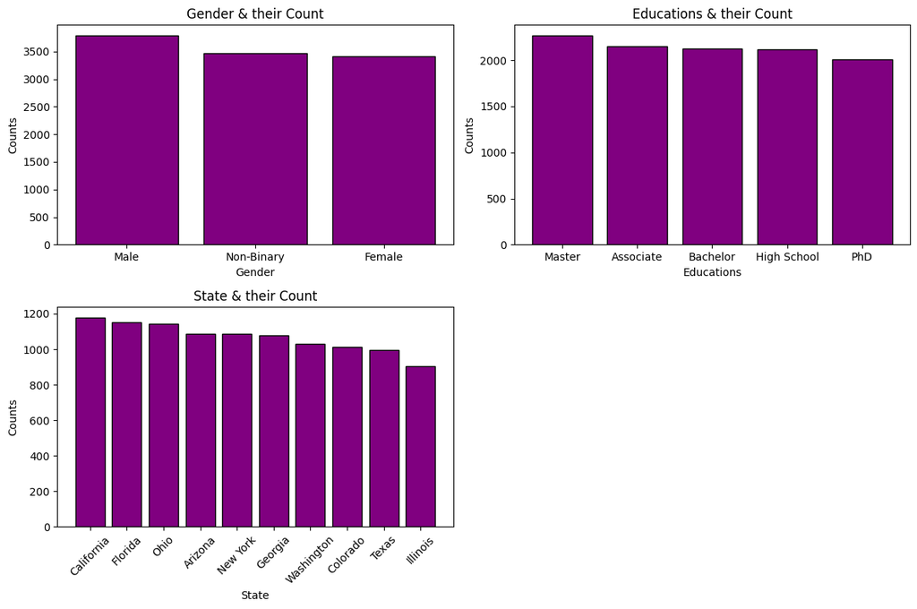

```python
# Calculate frequency count of Gender column
gen_count = Cust_Data["Gender"].value_counts()

# Calculate frequency count of Education column
edu_count = Cust_Data["Education"].value_counts()

# Calculate frequency count of State column
state_count = Cust_Data["State"].value_counts()

# Create a figure with specified size
plt.figure(figsize = (12,8))

#-------------------------------------------------------------------------------
# -------- Gender Bar Chart --------
# Create first subplot (2 rows, 2 columns, position 1)
plt.subplot(2,2,1)

# Plot bar chart for Gender counts
plt.bar(gen_count.index, gen_count.values, color="purple", edgecolor="black")

# Label x-axis
plt.xlabel("Gender")

# Label y-axis
plt.ylabel("Counts")

# Title of the plot
plt.title("Gender & their Count")

#--------------------------------------------------------------------------------
# -------- Education Bar Chart --------
# Create second subplot (2 rows, 2 columns, position 2)
plt.subplot(2,2,2)

# Plot bar chart for Education counts
plt.bar(edu_count.index, edu_count.values, color="purple", edgecolor='black')

# Label x-axis
plt.xlabel("Educations")

# Label y-axis
plt.ylabel("Counts")

# Title of the plot
plt.title("Educations & their Count")

#------------------------------------------------------------------------------------
# -------- State Bar Chart --------
# Create third subplot (2 rows, 2 columns, position 3)
plt.subplot(2,2,3)

# Plot bar chart for State counts
plt.bar(state_count.index, state_count.values, color="purple", edgecolor="black")

# Label x-axis
plt.xlabel("State")

# Label y-axis
plt.ylabel("Counts")

# Title of the plot
plt.title("State & their Count")

# Rotate x-axis labels for better readability
plt.xticks(rotation = 45)

# Adjust spacing between subplots to avoid overlap
plt.tight_layout()

# Display all plots
plt.show()

#----------------------------------------------------------------------------------------
```

#### Gender Distribution

The gender bar chart shows a fairly balanced distribution across Male, Female, and Non-Binary customers. No single gender category overwhelmingly dominates the dataset, indicating an inclusive and diverse customer base.

Customer behavior analysis should not assume gender bias, as all gender groups are well represented.

#### Education Level Distribution

The education distribution reveals that customers across High School, Bachelor’s, Associate, Master’s, and PhD levels are fairly evenly spread. Slightly higher representation is observed among customers with Master’s and Associate degrees, while PhD holders form the smallest group.

The dataset captures customers from varied educational backgrounds, making it suitable for analyzing education-based behavioral patterns without heavy class imbalance.

#### State-wise Customer Distribution

The state-wise bar chart indicates that customers are distributed across multiple states, with California, Florida, and Ohio having the highest customer counts. States like Illinois and Texas have relatively lower representation.

While the customer base spans multiple regions, certain states contribute a larger share of customers, which may warrant region-specific engagement strategies.

The bar charts indicate a well-balanced customer distribution across gender and education levels, with moderate regional variation across states.

Scatterplot:Age vs Monthly Spend

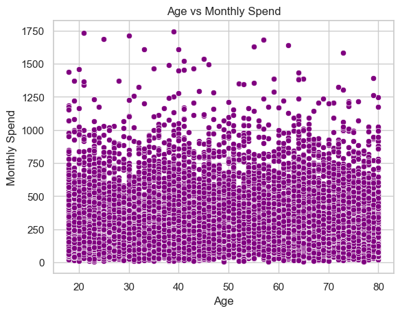

```python
# Set seaborn style for better aesthetics
sns.set(style="whitegrid")

# Create a scatter plot between Age and MonthlySpend
sns.scatterplot(
    x=Cust_Data['Age'],              # X-axis: Age of customers
    y=Cust_Data['MonthlySpend'],     # Y-axis: Monthly spending
    color="purple"                   # Color of scatter points
)

# Label x-axis
plt.xlabel("Age")

# Label y-axis
plt.ylabel("Monthly Spend")

# Title of the plot
plt.title("Age vs Monthly Spend")

# Display the plot
plt.show()
```

#### Age vs Monthly Spend (Scatter Plot)

The scatter plot displays the relationship between customer age and monthly spending. The data points are widely scattered across all age groups, with no clear upward or downward trend.

Customers across the entire age range (18 to 80 years) exhibit similar spending behavior, indicating that spending is not strongly influenced by age. Both younger and older customers show low, medium, and high spending values.

The absence of a visible linear pattern suggests a weak or no correlation between age and monthly spend. High-spending customers are observed at almost all age levels rather than being concentrated within a specific age group.

Age alone is not a strong predictor of customer spending. Therefore, age-based segmentation may not be effective for targeting high-spending customers, and other factors such as lifestyle or engagement behavior should be considered instead.

The scatter plot shows no clear relationship between age and monthly spending, indicating that customer spending patterns are largely age-independent.

KDE: Spending behavior by education level or marital status

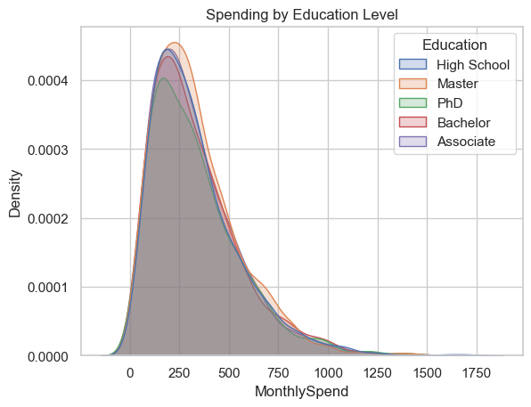

```python
# Create a Kernel Density Estimate (KDE) plot
# This shows the distribution of Monthly Spend for different Education levels
sns.kdeplot(
    data=Cust_Data,                  # Dataset used for plotting
    x='MonthlySpend',                # Variable on x-axis
    hue='Education',                 # Separate distributions by Education level
    fill=True                        # Fill the area under the KDE curves
)

# Title of the plot
plt.title("Spending by Education Level")

# Display the plot
plt.show()
```

#### Spending by Education Level (KDE Plot)

The KDE plot compares the distribution of monthly spending across different education levels. All education groups show a similar right-skewed distribution, indicating that most customers spend lower to moderate amounts, with a small number of high spenders in each group.

The density curves for High School, Bachelor’s, Associate, Master’s, and PhD overlap substantially, suggesting that spending behavior is largely consistent across education levels. While minor differences in peak density are visible, no education group shows a distinctly higher or lower spending pattern.

The long right tail present in all curves indicates the presence of high-value customers across every education category rather than being concentrated within a specific group.

Education level does not appear to strongly influence monthly spending behavior. Therefore, education-based segmentation may have limited impact on identifying high-spending customers.

The KDE plot shows heavily overlapping spending distributions across education levels, indicating similar spending behavior regardless of educational background.

## Bivariate Analysis

**Objective:** To examine how different customer attributes relate to one another and identify meaningful patterns.

#### Correlation Matrix (Numeric Variables)

Used to examine linear relationships between **numerical column**, helping assess the strength and direction of association.

#### Crosstab Analysis: Gender vs Marital Status

Displays the frequency distribution across gender and marital status categories to understand demographic composition.

#### Grouped Statistics: Average Monthly Spend

- Average Monthly Spend by **State**
- Average Monthly Spend by **Education Level**
- Average Monthly Spend by **Gender**

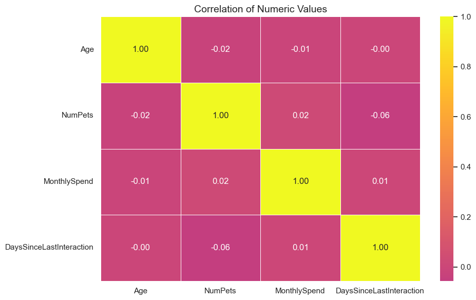

```
Crosstab: Gender vr Marital Status
```

| Married Gender | No | Yes |
| --- | --- | --- |
| Female | 52.651626 | 47.348374 |
| Male | 49.907676 | 50.092324 |
| Non-Binary | 54.566407 | 45.433593 |

```
Average Monthly spend by state:
 Gender
Female        331.361310
Male          333.174068
Non-Binary    330.147240
Name: MonthlySpend, dtype: float64

Average monthly spend by Education:
 Education
Master         334.252305
High School    332.215712
Bachelor       331.884753
PhD            331.690090
Associate      327.884408
Name: MonthlySpend, dtype: float64

Average monthly spend by Gender:
 State
Arizona       341.489135
Ohio          340.187860
California    339.183492
Illinois      332.589591
New York      332.151244
Washington    329.444078
Georgia       328.354648
Florida       327.696892
Colorado      323.083462
Texas         319.506770
Name: MonthlySpend, dtype: float64
```

```python
# Bivariate Analysis

# -------------------------------------------------------------
# Correlation analysis between numerical variables
# -------------------------------------------------------------
# Compute correlation matrix
corr_matrix = Cust_Data.corr(numeric_only=True)

# Plot heatmap
plt.figure(figsize=(10, 6))
sns.heatmap(
    corr_matrix,
    annot=True,          # Show correlation values
    fmt=".2f",           # 2 decimal places
    cmap="plasma",     # Color theme
    center=0,            # Center at 0 for better positive/negative contrast
    linewidths=0.5       # Add small grid lines
)

plt.title("Correlation of Numeric Values", fontsize=14)
plt.tight_layout()
plt.show()

#----------------------------------------------------------------
# crosstab analysis gender vs marital status
#----------------------------------------------------------------

# Create a cross-tabulation between Gender and Marital Status
# normalize='index' converts counts into row-wise percentages

gender_marital_pct = pd.crosstab(
    Cust_Data['Gender'],
    Cust_Data['Married'],
    normalize='index'         # Normalize across each Gender (row-wise)
) * 100                       # Convert proportions to percentages

# Display the percentage table
print("\nCrosstab: Gender vr Marital Status")
display(gender_marital_pct)

#--------------------------------------------------------------------
# Average Monthly Spend by different categories
#--------------------------------------------------------------------

# Calculate the average Monthly Spend for customers in each state
state_avg_spend = (
    Cust_Data
    .groupby('State')['MonthlySpend']   # Group by State and select MonthlySpend
    .mean()                             # Compute mean MonthlySpend per State
    .sort_values(ascending=False)       # Sort states from highest to lowest average spend
)

#-----------------------------------------------------------------------------------------
# Calculate the average Monthly Spend for each education category
edu_avg_spend = (
    Cust_Data
    .groupby('Education')['MonthlySpend']
    .mean()
    .sort_values(ascending=False)
)

#-----------------------------------------------------------------------------------------
# Calculate the average Monthly Spend for each gender category
gender_avg_spend = (
    Cust_Data
    .groupby('Gender')['MonthlySpend']
    .mean()
)

# Display ths result
print("Average Monthly spend by state:\n",gender_avg_spend)
print("\nAverage monthly spend by Education:\n",edu_avg_spend)
print("\nAverage monthly spend by Gender:\n",state_avg_spend)

#----------------------------------------------------------------------------------------------
```

## Correlation Matrix Analysis

The correlation matrix evaluates the linear relationships among the numerical variables: **Age, Number of Pets (NumPets), Monthly Spend and Days Since Last Interaction**.

All correlation coefficients in the matrix are very close to zero, indicating weak or negligible linear relationships between the variables.

### Key Observations

- **Age vs Monthly Spend (−0.01):** The correlation is nearly zero, suggesting that age does not meaningfully influence customer spending behavior.
- **Age vs NumPets (−0.02):** There is no significant relationship between customer age and the number of pets owned.
- **Age vs DaysSinceLastInteraction (−0.00):** Customer age does not appear to affect engagement frequency.
- **NumPets vs Monthly Spend (0.02):** The number of pets owned has no meaningful impact on monthly spending.
- **NumPets vs DaysSinceLastInteraction (−0.06):** A very weak negative relationship exists, but it is too small to be practically significant.
- **Monthly Spend vs DaysSinceLastInteraction (0.01):** Spending behavior is not strongly related to customer interaction frequency.

Since all correlation values are close to zero, there is no strong linear relationship among the numerical variables in the dataset. This suggests that customer spending and engagement behavior are likely influenced by multiple factors rather than any single numerical variable.

#### Crosstab: Gender vs Marital Status (Percentages)

Female customers: ~52.6% unmarried, ~47.4% married  
Male customers: ~49.9% unmarried, ~50.1% married  
Non-binary customers: ~54.6% unmarried, ~45.4% married

Marital status is fairly balanced across all gender categories, with only minor variations. There is no strong gender-based pattern in marital status distribution, indicating that gender and marital status are largely independent in this dataset.

#### Average Monthly Spend by Gender

Male: ~333  
Female: ~331  
Non-binary: ~330

The average monthly spend is almost identical across genders, with only negligible differences. Spending behavior does not vary meaningfully by gender, supporting the t-test result of no significant gender-based spending difference.

#### Average Monthly Spend by Education Level

Average monthly spending is similar across all education levels, ranging roughly between 328 and 334. No education group shows distinctly higher or lower spending behavior.

Education level has minimal influence on monthly spending, which aligns with the ANOVA results showing no statistically significant differences.

#### Average Monthly Spend by State

Average spending varies slightly across states, with Arizona, Ohio, and California showing marginally higher averages, while Texas and Colorado are on the lower end.

Although minor variations exist, the differences are not large enough to indicate strong regional spending disparities. State-wise spending behavior is broadly consistent, suggesting that geographic location alone may not be a strong driver of spending differences.

Bivariate analysis reveals minimal relationships between demographic attributes and spending, indicating that customer spending behavior is largely independent of age, gender, education, and geography.

## Formulate Hypotheses

Convert business questions into appropriate statistical tests to enable data-driven decision making.

**• Gender-based Spending Behavior**  
Business Question: Do males and females spend differently?  
Statistical Test: **Independent t-test**

**• Education Level and Monthly Spend**  
Business Question: Does education level impact average monthly spend?  
Statistical Test: **One-way ANOVA**

**• Marital Status and Pet Ownership**  
Business Question: Is marital status related to the number of pets owned? (Only for DS Students)  
Statistical Test: **Chi-square test**

**• Age and Activity Level**  
Business Question: Are older people less active?  
Statistical Test: **Correlation Analysis** (Age vs DaysSinceLastInteraction)

**• State-wise Spending Variation**  
Business Question: Does spending vary significantly across states?  
Statistical Test: **ANOVA**

```python
from scipy.stats import ttest_ind, f_oneway, chi2_contingency, pearsonr

#-------------------------------------------------------------------------------
#--------------Independent t_test-------------------------
#-------------------------------------------------------------------------------

# Extract Monthly Spend for Male customers
male_spend = Cust_Data[Cust_Data['Gender'] == 'Male']['MonthlySpend']

# Extract Monthly Spend for Female customers
female_spend = Cust_Data[Cust_Data['Gender'] == 'Female']['MonthlySpend']

# Perform independent two-sample t-test (Welch’s t-test)
# equal_var=False is used when population variances are assumed to be unequal
t_stat, p_value = ttest_ind(
    male_spend,
    female_spend,
    equal_var=False
)

# Display t-statistic and p-value
print("Independent t-test: Monthly Spend by Gender")
print(f"T-statistic:{t_stat:.4f}")
print(f"P-value_gender:{p_value:.4f}\n")

#--------------------------------------------------------------------------------------------
#-----------------One-way Anova---------------------------------
#--------------------------------------------------------------------------------------------

# Create a list of MonthlySpend arrays for each Education group
# Each element in the list represents one education category
groups = [
    group['MonthlySpend'].values
    for name, group in Cust_Data.groupby('Education')
]

# Perform one-way ANOVA test
# This checks whether the mean Monthly Spend differs across Education levels
f_stat, p_value = f_oneway(*groups)

# Display F-statistic and p-value
print("One-way ANOVA: Monthly Spend by Education level")
print(f"F-statistic:{f_stat:.4f}")
print(f"P-value_Edu:{p_value:.4f}")

#------------------------------------------------------------------------------------------------------
#--------------Chi-square test of independence---------------------------
#------------------------------------------------------------------------------------------------------

# Create a contingency table between Marital Status and Number of Pets
# Rows represent Married status, columns represent different NumPets categories
contingency = pd.crosstab(
    Cust_Data['Married'],     # Marital status categories
    Cust_Data['NumPets']      # Number of pets categories
)

# Perform Chi-square test of independence
# This tests whether Marital Status and Number of Pets are statistically independent
chi2, p_value, dof, expected = chi2_contingency(contingency)

# Display only the p-value
print("\nChi-square Test: Marital Status vs Number of Pets")
print(f"Chi-square statistic: {chi2:.4f}")
print(f"Degrees of freedom: {dof}")
print(f"P-value: {p_value:.4f}\n")

#-----------------------------------------------------------------------------------------------------------
# -----------------Correlation analysis-------------------------
# ----------------------------------------------------------------------------------------------------------

#  Calculate Pearson correlation
corr, p_value = pearsonr(
    Cust_Data['Age'],
    Cust_Data['DaysSinceLastInteraction']
)

# Display results
print("Correlation Analysis: Age vs Days Since Last Interaction")
print(f"Correlation coefficient: {corr:.4f}")
print(f"P-value: {p_value:.4f}\n")

#----------------------------------------------------------------------------------------------------------
#------------------One-way ANOVA---------------------
#-----------------------------------------------------------------------------------------------------------

# Create a list of MonthlySpend arrays for each State
# Each array represents MonthlySpend values of customers from one state
state_groups = [
    group['MonthlySpend'].values
    for name, group in Cust_Data.groupby('State')
]

# Perform one-way ANOVA test
# This checks whether the mean Monthly Spend differs significantly across States

f_stat, p_value = f_oneway(*state_groups)

# Display only the p-value
print("One-way ANOVA: Monthly Spend by State")
print(f"F-statistic: {f_stat:.4f}")
print(f"P-value: {p_value:.4f}")

#---------------------------------------------------------------------------------------------------------------
```

```
Independent t-test: Monthly Spend by Gender
T-statistic:0.3391
P-value_gender:0.7345

One-way ANOVA: Monthly Spend by Education level
F-statistic:0.2288
P-value_Edu:0.9224

Chi-square Test: Marital Status vs Number of Pets
Chi-square statistic: 177.6395
Degrees of freedom: 4
P-value: 0.0000

Correlation Analysis: Age vs Days Since Last Interaction
Correlation coefficient: -0.0040
P-value: 0.6817

One-way ANOVA: Monthly Spend by State
F-statistic: 1.1178
P-value: 0.3457
```

### Insights from Hypothesis Testing Analysis

**Spending behavior** remains largely uniform across gender, education levels, and states, indicating minimal demographic influence on monthly expenditure.

**Engagement recency** does not show meaningful variation across age groups, suggesting that age is not a strong determinant of interaction frequency.

**Pet ownership** emerges as the primary distinguishing factor, demonstrating a significant association with marital status.

## Run Hypothesis Tests

**Purpose:** Validate or reject analytical assumptions using appropriate statistical tests with a defined level of confidence.

**• Define Null and Alternate Hypotheses**  
Formulate a **null hypothesis (H₀)** representing no effect or no difference, and an **alternate hypothesis (H₁)** indicating the presence of a statistically significant effect or relationship.

**• Select Appropriate Statistical Test**  
Choose the test based on variable types (categorical or numerical), number of groups, and the objective of comparison (e.g., t-test, ANOVA, chi-square, correlation).

**• Check Statistical Assumptions**  
Verify key assumptions including **normality**, **independence of observations**, and **homogeneity of variance** to ensure the validity of the test results.

**• Interpret Results**  
Evaluate **p-values** and **confidence intervals** to determine statistical significance and assess the strength and reliability of the findings.

### Understanding Statistical Hypotheses

**Null Hypothesis (H₀)**

The null hypothesis assumes that there is **no effect**, **no difference**, or **no relationship** between variables. It represents the **default business assumption** and serves as the baseline against which statistical evidence is evaluated. Statistical tests are designed to assess whether sufficient evidence exists to **reject H₀**.

**Alternate Hypothesis (H₁)**

#### 1. Gender-based Spending Behavior

**Null Hypothesis (H₀):** There is no significant difference in average monthly spend between male and female customers.

**Alternate Hypothesis (H₁):** There is a significant difference in average monthly spend between male and female customers.

**Test Used:** Independent t-test

**Result & Interpretation:**  
Since the p-value (0.7345) is greater than 0.05, the null hypothesis was not rejected. This indicates that gender does not significantly influence monthly spending.

#### 2. Education Level and Monthly Spend

**Null Hypothesis (H₀):** Average monthly spend is equal across all education levels.

**Alternate Hypothesis (H₁):** At least one education level differs in average monthly spend.

**Test Used:** One-way ANOVA

**Result & Interpretation:**  
With a p-value of 0.9224 (> 0.05), no statistically significant difference was observed. Education level does not impact monthly spending.

#### 3. Marital Status and Pet Ownership

**Null Hypothesis (H₀):** Marital status and number of pets owned are independent.

**Alternate Hypothesis (H₁):** Marital status and number of pets owned are associated.

**Test Used:** Chi-square test of independence

**Result & Interpretation:**  
The p-value (< 0.05) indicates a statistically significant association between marital status and pet ownership.

#### 4. Age and Activity Level

**Null Hypothesis (H₀):** There is no relationship between age and days since last interaction.

**Alternate Hypothesis (H₁):** A significant relationship exists.

**Test Used:** Correlation analysis

**Result & Interpretation:**  
The correlation was weak and statistically insignificant (p = 0.6817), suggesting that customer age does not affect engagement level.

#### 5. State-wise Spending Variation

**Null Hypothesis (H₀):** Mean monthly spend is the same across all states.

**Alternate Hypothesis (H₁):** At least one state differs.

**Test Used:** One-way ANOVA

**Result & Interpretation:**  
With a p-value of 0.3457, no statistically significant state-wise spending differences were observed.

#### Normality Assumption

**Purpose:**  
To check whether numerical variables (e.g., MonthlySpend) follow a normal distribution.

**Method Used:**  
Shapiro–Wilk test  
Visual inspection using histogram and KDE plots

```
Assumption of Normality Distribution:
Shapiro_Test:ShapiroResult(statistic=np.float64(0.8995173951950916), pvalue=np.float64(8.932895405321421e-64))
```

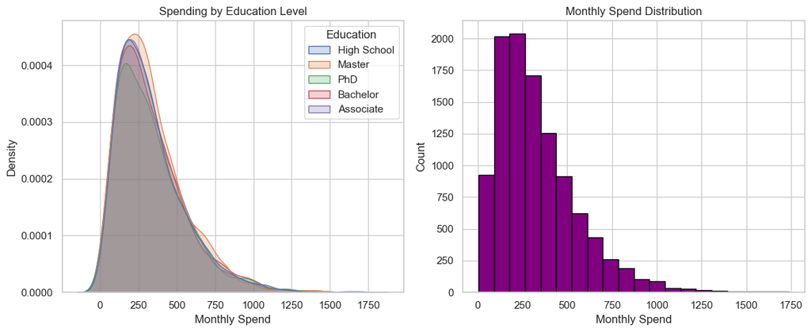

```python
from scipy.stats import shapiro
#-------------------------------------------------------------------
#-----------Shapiro–Wilk test------------
#-------------------------------------------------------------------

# Perform Shapiro–Wilk test for normality on MonthlySpend
# This test checks whether the data follows a normal distribution
shapiro_test = shapiro(Cust_Data['MonthlySpend'])

# Display the test statistic and p-value
print("Assumption of Normality Distribution:")
print(f"Shapiro_Test:{shapiro_test:}")

#----------------------------------------------------------------------
# KDE plot + Histogram
#----------------------------------------------------------------------

# Create one figure with 2 subplots
plt.figure(figsize=(12,5))

# ---------------- KDE Plot ----------------
plt.subplot(1,2,1)
sns.kdeplot(
    data=Cust_Data,
    x='MonthlySpend',
    hue='Education',
    fill=True
)
plt.title("Spending by Education Level")
plt.xlabel("Monthly Spend")
plt.ylabel("Density")

# ---------------- Histogram ----------------
plt.subplot(1,2,2)
plt.hist(Cust_Data['MonthlySpend'], bins=20, color="purple", edgecolor="black")
plt.xlabel("Monthly Spend")
plt.ylabel("Count")
plt.title("Monthly Spend Distribution")

# Adjust layout
plt.tight_layout()
plt.show()

#---------------------------------------------------------------------------------------
```

**Interpretation:**  
The Shapiro–Wilk test indicated deviation from normality (p < 0.05). However, given the large sample size (over 10,000 observations), parametric tests were considered appropriate under the Central Limit Theorem.

Normality was assessed using the Shapiro–Wilk test, which indicated deviation from normality due to the large sample size. Visual inspection through histograms and KDE plots showed a right-skewed but stable distribution. Given the large number of observations, parametric tests were applied under the Central Limit Theorem.

#### Independence of Observations

**Purpose:**  
To ensure that each observation in the dataset is independent of others.

**Method Used:**  
Verified through data structure and collection logic.

**Conclusion:**  
The assumption of independence of observations is satisfied.

#### Homogeneity of Variance

**Purpose:**  
To check whether the variance of the dependent variable is equal across comparison groups.

**Method Used:**  
Levene’s test

```python
from scipy.stats import levene
#-------------------------------------------------------------------
#-------------Levene’s test--------------
#-------------------------------------------------------------------

# Perform Levene’s test for equality of variances
# This test checks whether the variances of MonthlySpend
# are equal between male and female customers
levene_test = levene(
    male_spend,    # MonthlySpend values for Male customers
    female_spend   # MonthlySpend values for Female customers
)

# Display the test statistic and p-value
print(f"Levene_Test:{levene_test}")
```

```
Levene_Test:LeveneResult(statistic=np.float64(0.1267563861615179), pvalue=np.float64(0.7218295518512636))
```

**Interpretation:**  
Levene’s test returned a p-value greater than 0.05, indicating equal variances across groups.

**Conclusion:**  
The assumption of homogeneity of variance is satisfied.

#### Business Insights

**1. Demographic Targeting Alone Is Ineffective**  
Age, gender, education level, and geographic location show minimal influence on monthly spending. Traditional demographic-based segmentation is unlikely to significantly improve revenue performance.

**2. Existence of a High-Value Customer Segment**  
The right-skewed spending distribution confirms the presence of a small premium customer group contributing disproportionately to revenue. Identifying, nurturing, and retaining these customers should be a strategic priority.

**3. Behavioral Segmentation Is the Key Growth Driver**  
Since demographic variables are weak predictors, customer engagement metrics, purchase frequency, recency of interaction, and transaction behavior are more likely to drive meaningful segmentation and targeted marketing strategies.

**4. Broad and Inclusive Market Positioning**  
The customer base is diverse and evenly distributed across demographic categories. Marketing communication should remain inclusive rather than focused on narrow demographic groups.

**5. Revenue Optimization Strategy**  
Business growth should focus on:

- High-value customer retention programs
- Loyalty and reward-based incentives
- Personalized recommendations
- Engagement-driven campaigns

These initiatives are likely to yield higher ROI compared to demographic-based promotions.

**6. Data Strategy Recommendation**  
Future analysis should incorporate behavioral, transactional, and lifestyle variables to better understand spending drivers, as numerical demographic attributes alone do not explain revenue variation.

#### Project Summary

This analysis examined customer demographics, spending patterns, and engagement behavior to identify key drivers of monthly spending. Univariate and bivariate analysis revealed that demographic attributes such as age, gender and education level show minimal influence on spending behavior. Statistical hypothesis testing further confirmed the absence of significant differences across these groups.

Correlation analysis indicated weak linear relationships among numerical variables, suggesting that spending patterns are not strongly explained by any single demographic factor. Although spending distribution is right-skewed, indicating the presence of a high-value customer segment, this pattern is consistent across demographic categories.

Overall, the findings suggest that customer spending behavior is largely demographic-independent and likely influenced by behavioral or transactional factors. Future business strategies should focus on behavioral segmentation, customer engagement metrics, and high-value customer retention to optimize revenue growth.